# Problema 4 CP 1

September 12, 2016

## Os dados

Os dados descrevem um rating 1-5 estrelas e marcadores do MovieLens, um serviço de recomendação de filmes. Contem 105339 ratings and 6138 marcações para 10329 filmes. Estes dadis foram criados por 668 usuários entre 03/04/1996 e 09/01/2016.

Usuários foram selecionados aleatoriamente. Todos os usuários selecionados avaliaram pelo menos 20 filmes. Sem informacão geográfica inclusa.

## Pergunta 1 _

A pergunta 1 basicamente é escolher uma n-logia, a escolhida por mim foi Premonição (Final Destination), uma sequência de filmes da década 2000 composta por cinco filmes. Para sabermos quais dos filmes da trilogia tem a melhor avaliação fazemos e qual tem mais variação. A figura abaixo mostra as ratings de cada um dos filmes, cada ponto vermelho representa uma avaliação, e o preto a média do filme.

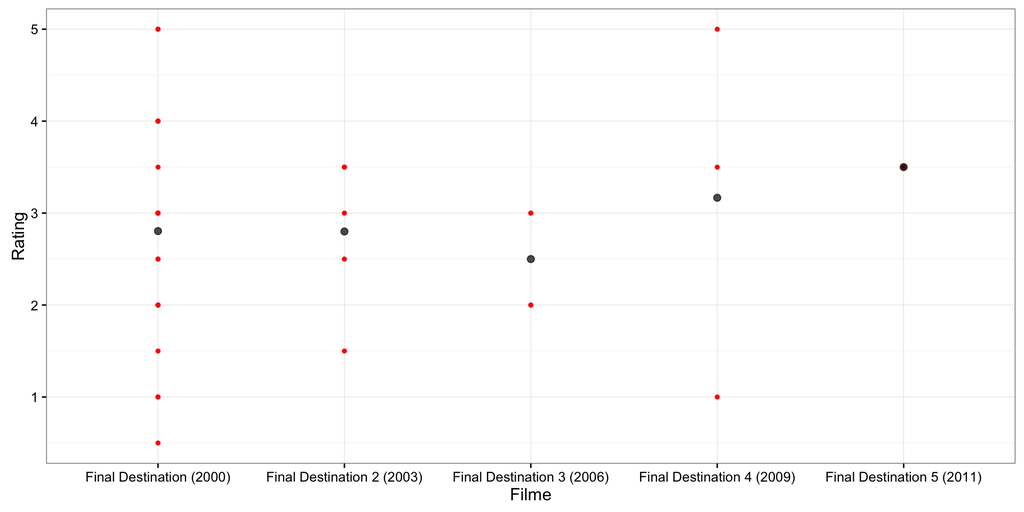

```r
# Filmes de Premonição
premonicao.filmes = subset(genres, genres$movieId == 3409 | genres$movieId == 6058
                           | genres$movieId == 43679 | genres$movieId == 71252 | genres$movieId == 88932)
# Avaliações dos filmes
ratings.premonicao = subset(ratings, ratings$movieId == 3409 | ratings$movieId == 6058
                           | ratings$movieId == 43679 | ratings$movieId == 71252 | ratings$movieId == 88932)
genres2 <- genres[,c(1,2)]
# Merge dos datasetes
ratings.premonicao <- merge(ratings.premonicao, genres2, by.movieId = "movieId")
ratings.premonicao <- unique(ratings.premonicao)
ratings.premonicao$title <- as.character(ratings.premonicao$title)
ratings.premonicao$title[ratings.premonicao$title=="Final Destination, The (Final Destination 4) (Final Destination in 3-D, The) (2009)"] <- "Final Destination 4 (2009)"
ratings.grouped = ratings.premonicao %>% group_by(title)
## Agrupando por mes e por tipo de despesa, e somando todos os gastos.
ratings.mean = ratings.grouped %>%
  summarize(media = mean(rating))
ratings.var = ratings.grouped %>%
  summarize(variacao = var(rating))

ggplot(ratings.premonicao, mapping= aes(x = title, y =rating)) +
    geom_point(size = 1, color="red") +
    geom_point(ratings.mean,
             colour = "black", size = 2, alpha = 0.7,
             mapping = aes(y = media, x = title))+
    labs(x='Filme', y = 'Rating')
```

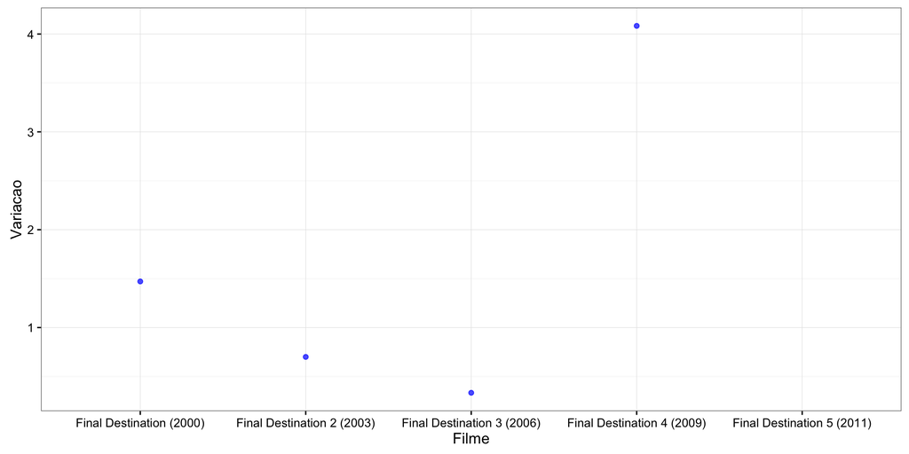

```r
ggplot(ratings.var, mapping=aes(x=title, y=variacao))+
  geom_point(colour = "blue", size = 1.5, alpha=0.7)+
  labs(x='Filme', y = 'Variacao')
```

Como essa amostra não representa todas as avaliações desse filme existentes no mundo, vamos usar inferência para tentarmos responder com um intervalo de confiança qual o melhor filme da sequencia.

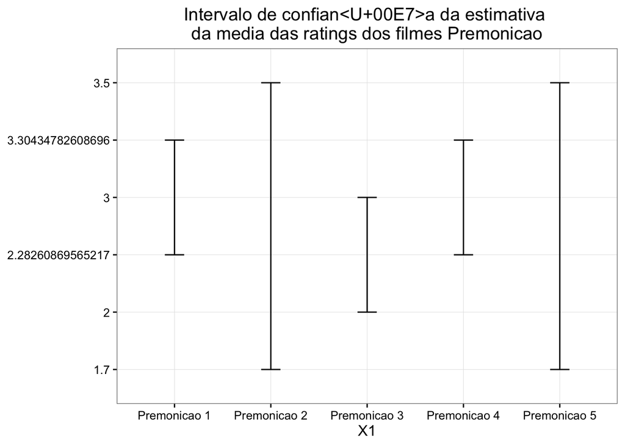

```r
library(resample)
#para isso precisamos separar cada filme
premonicao1 = ratings.premonicao %>% filter(movieId == 3409)
premonicao2 = ratings.premonicao %>% filter(movieId == 6058)
premonicao3 = ratings.premonicao %>% filter(movieId == 43679)
premonicao4 = ratings.premonicao %>% filter(movieId == 71252)
premonicao5 = ratings.premonicao %>% filter(movieId == 88932)

bootstrap.media.premonicao1 = bootstrap(premonicao1$rating, mean, R = 1000)
media.premonicao1 = CI.percentile(bootstrap.media.premonicao1, probs = c(.025, .975))

bootstrap.media.premonicao2 = bootstrap(premonicao2$rating, mean, R = 1000)
media.premonicao2 = CI.percentile(bootstrap.media.premonicao2, probs = c(.025, .975))

bootstrap.media.premonicao3 = bootstrap(premonicao3$rating, mean, R = 1000)
media.premonicao3 = CI.percentile(bootstrap.media.premonicao3, probs = c(.025, .975))

bootstrap.media.premonicao4 = bootstrap(premonicao4$rating, mean, R = 1000)
media.premonicao4 = CI.percentile(bootstrap.media.premonicao1, probs = c(.025, .975))

bootstrap.media.premonicao5 = bootstrap(premonicao5$rating, mean, R = 1000)
media.premonicao5 = CI.percentile(bootstrap.media.premonicao2, probs = c(.025, .975))

# Unindo os dados
filmes.premonicao <- data.frame(
  rbind(
    c("Premonicao 1", media.premonicao1),
    c("Premonicao 2", media.premonicao2),
    c("Premonicao 3", media.premonicao3),
    c("Premonicao 4", media.premonicao4),
    c("Premonicao 5", media.premonicao5)
  )
)

ggplot(filmes.premonicao, aes(x = X1, ymin = X2, ymax = X3)) +
  geom_errorbar(width = .2) +
  ggtitle("Intervalo de confiança da estimativa \nda media das ratings dos filmes Premonicao")
```

## Pergunta 2 _

Normalmente os filmes têm vários gêneros. Existe uma relação entre em quantos gêneros os filmes se encaixam e a avaliação que os filmes recebem? Para isso vamos utilizar toda a nossa amostra disponibilizada pelo professor. Aqui montamos um dataset com o id do filme, o numero de generos e a média das avaliações. Agora vamos utilizar a média para vermos se a quantidade de gêneros tem alguma correlação com as avaliações

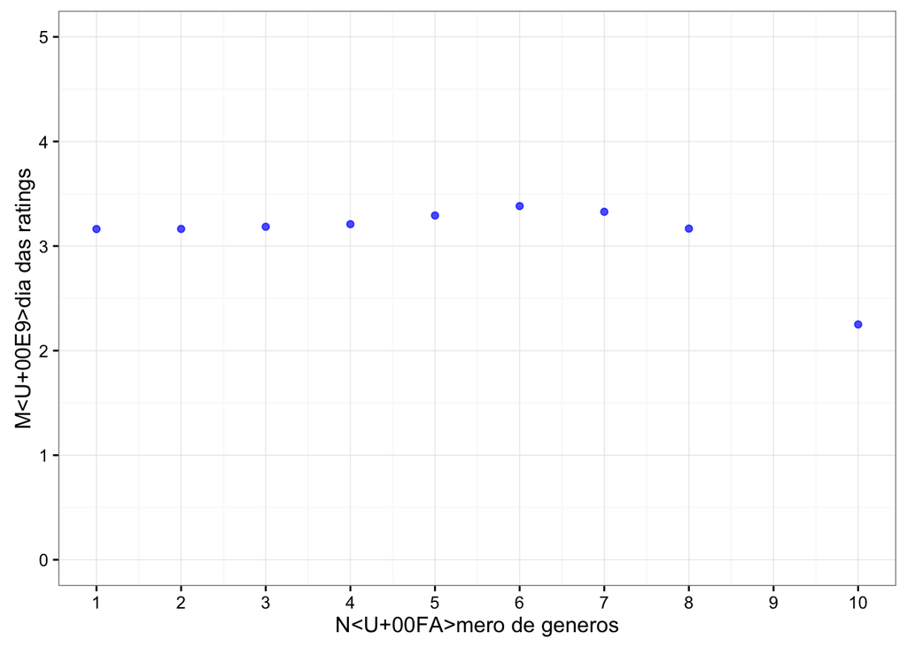

```r
media.filmes <- data.frame(movieId=numeric(0), genres.cardinality=numeric(0), media=numeric(0))

for(id in 1:149532){
 #se existir filme com id n
 if(nrow( subset(genres, movieId == id) ) > 0){
   # pega a avaliação dos filmes
   id <- as.numeric(id)
   movie.ratings <- subset(ratings, movieId == id)

   if(nrow(movie.ratings) > 0){
     # se filme possui um gênero e é no genre
     if(length(genres$genre[genres$movieId==id]) == 1 & genres$genre[genres$movieId==id]  == "0"){
       v.genres.cardinality <- 0
     }
     else{
         v.genres.cardinality <- as.numeric(sum(genres$movieId == id))
     }
     v.media <- mean(movie.ratings$rating)
     # adiciona na tabela
     media.filmes <- rbind(media.filmes, data.frame(movieId = id, genres.cardinality = v.genres.cardinality, media = v.media))
   }
 }
}

media.filmes.g <- media.filmes %>% group_by(genres.cardinality)
media.groups.genre = media.filmes.g %>%
  summarize(media.cardinality = mean(media))

ggplot(media.groups.genre, mapping=aes(x=genres.cardinality, y=media.cardinality))+
  geom_point(colour = "blue", size = 1.5, alpha=0.7)+
  labs(x='Número de generos', y = 'Média das ratings')+ ylim(0,5)+
  scale_x_continuous(breaks=seq(0,10,1))
```

Como podemos ver o número de gêneros por filme não influencia muito nas avaliações. Só os com generos acima do normal(10) que apresenta uma queda na média de avaliações que pode ser dado pelo fato de filme com 10 generos praticamente não existir e isso levar a presumir que pode ser obra de BOTS.